# Chapter 24: Model Building

### Seasonal Saturday effect

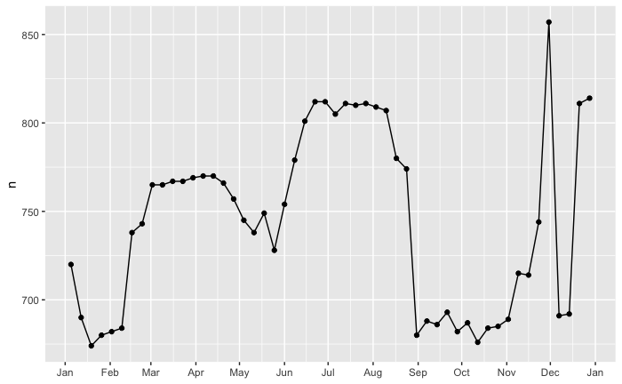

Let’s create a term variable that roughly captures the three school terms, and check our work with a plot:

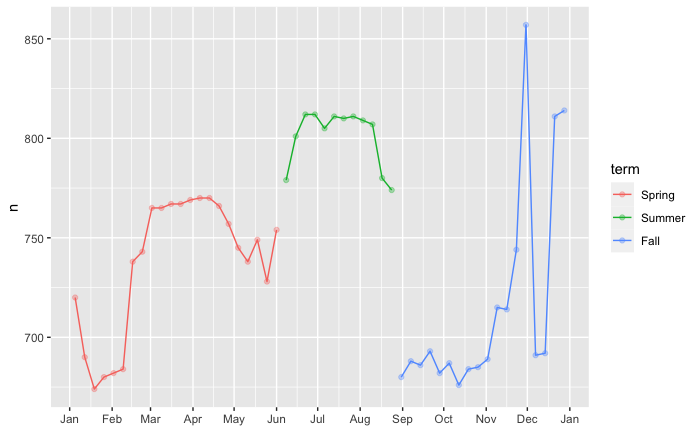

IT’s useful to see how this new variable affects the other days of the week:

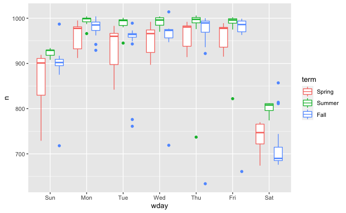

Let’s fit a model with terms of the day of the week by term:

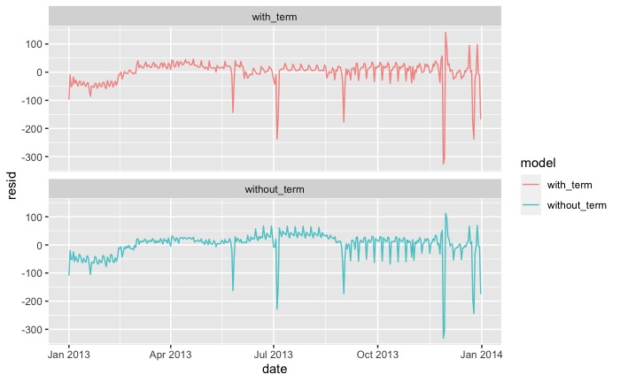

Let’s overlay the predictions from the model to the raw data:

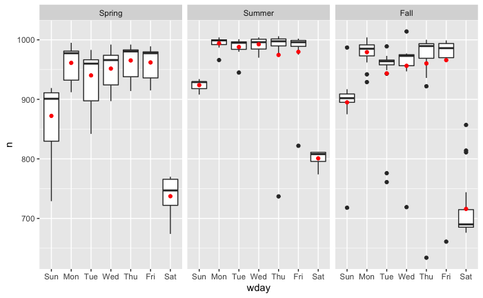

The model is finding the mean effect but the outliers are pulling the trends away from the typical value. We can help this with a robust model.

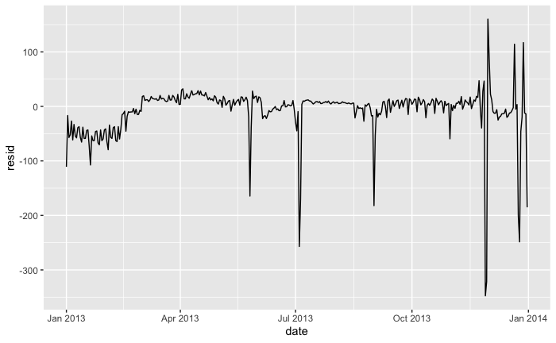

```r
mod3 <- MASS::rlm(n ~ wday * term, data = daily)

daily %>%
  add_residuals(mod3, "resid") %>%
  ggplot(aes(date, resid)) +
  geom_hline(yintercept = 0, size = 0, color = "white") +
  geom_line()
```

The predictions with the robust model:

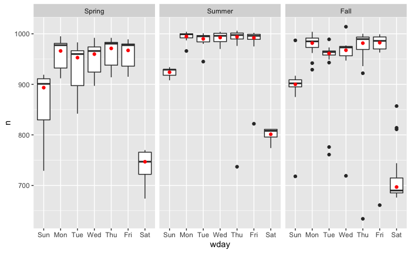

### Time of year: an alternative approach

A simple linear trend isn’t adequate to capture the pattern in the data so we could try using a natural spline to fit a smooth curve across the year:

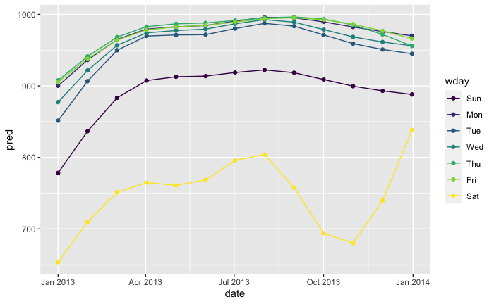